# PART-1

# PART-2

```python
#2Q1 :- Read the data set, clean the data and prepare final dataset to be used for analysis.
```

```python
path = 'DS+-+Part2+-+Basketball.csv'
data = pd.read_csv(path)
data
```

|  | Team | Tournament | Score | PlayedGames | WonGames | DrawnGames | LostGames | BasketScored | BasketGiven | TournamentChampion | Runner-up | TeamLaunch | HighestPositionHeld |
| --- | --- | --- | --- | --- | --- | --- | --- | --- | --- | --- | --- | --- | --- |
| 0 | Team 1 | 86 | 4385 | 2762 | 1647 | 552 | 563 | 5947 | 3140 | 33 | 23 | 1929 | 1 |
| 1 | Team 2 | 86 | 4262 | 2762 | 1581 | 573 | 608 | 5900 | 3114 | 25 | 25 | 1929 | 1 |
| 2 | Team 3 | 80 | 3442 | 2614 | 1241 | 598 | 775 | 4534 | 3309 | 10 | 8 | 1929 | 1 |
| 3 | Team 4 | 82 | 3386 | 2664 | 1187 | 616 | 861 | 4398 | 3469 | 6 | 6 | 1931to32 | 1 |
| 4 | Team 5 | 86 | 3368 | 2762 | 1209 | 633 | 920 | 4631 | 3700 | 8 | 7 | 1929 | 1 |
| ... | ... | ... | ... | ... | ... | ... | ... | ... | ... | ... | ... | ... | ... |
| 56 | Team 57 | 1 | 34 | 38 | 8 | 10 | 20 | 38 | 66 | - | - | 2009-10 | 20 |
| 57 | Team 58 | 1 | 22 | 30 | 7 | 8 | 15 | 37 | 57 | - | - | 1956-57 | 16 |
| 58 | Team 59 | 1 | 19 | 30 | 7 | 5 | 18 | 51 | 85 | - | - | 1951~52 | 16 |
| 59 | Team 60 | 1 | 14 | 30 | 5 | 4 | 21 | 34 | 65 | - | - | 1955-56 | 15 |
| 60 | Team 61 | 1 | - | - | - | - | - | - | - | - | - | 2017~18 | 9 |

61 rows × 13 columns

```python
data.head()
```

|  | Team | Tournament | Score | PlayedGames | WonGames | DrawnGames | LostGames | BasketScored | BasketGiven | TournamentChampion | Runner-up | TeamLaunch | HighestPositionHeld |
| --- | --- | --- | --- | --- | --- | --- | --- | --- | --- | --- | --- | --- | --- |
| 0 | Team 1 | 86 | 4385 | 2762 | 1647 | 552 | 563 | 5947 | 3140 | 33 | 23 | 1929 | 1 |
| 1 | Team 2 | 86 | 4262 | 2762 | 1581 | 573 | 608 | 5900 | 3114 | 25 | 25 | 1929 | 1 |
| 2 | Team 3 | 80 | 3442 | 2614 | 1241 | 598 | 775 | 4534 | 3309 | 10 | 8 | 1929 | 1 |
| 3 | Team 4 | 82 | 3386 | 2664 | 1187 | 616 | 861 | 4398 | 3469 | 6 | 6 | 1931to32 | 1 |
| 4 | Team 5 | 86 | 3368 | 2762 | 1209 | 633 | 920 | 4631 | 3700 | 8 | 7 | 1929 | 1 |

```python
# For knowing number of columns and rows
data.shape
```

```
(61, 13)
```

```python
# For checking data types
data.info()
```

```
<class 'pandas.core.frame.DataFrame'>
RangeIndex: 61 entries, 0 to 60
Data columns (total 13 columns):
 #   Column               Non-Null Count  Dtype
---  ------               --------------  -----
 0   Team                 61 non-null     object
 1   Tournament           61 non-null     int64
 2   Score                61 non-null     object
 3   PlayedGames          61 non-null     object
 4   WonGames             61 non-null     object
 5   DrawnGames           61 non-null     object
 6   LostGames            61 non-null     object
 7   BasketScored         61 non-null     object
 8   BasketGiven          61 non-null     object
 9   TournamentChampion   61 non-null     object
 10  Runner-up            61 non-null     object
 11  TeamLaunch           61 non-null     object
 12  HighestPositionHeld  61 non-null     int64
dtypes: int64(2), object(11)
memory usage: 6.3+ KB
```

```python
# Finding null values and their number if present
data.isnull().sum()
```

```
Team                   0
Tournament             0
Score                  0
PlayedGames            0
WonGames               0
DrawnGames             0
LostGames              0
BasketScored           0
BasketGiven            0
TournamentChampion     0
Runner-up              0
TeamLaunch             0
HighestPositionHeld    0
dtype: int64
```

There were no null values in the given dataset.

```python
#Checking for duplicates
dupes = data.duplicated()
```

```python
# Identifying missing values
pd.DataFrame(data.isnull().sum(),columns=['Number of missing values'])
```

|  | Number of missing values |
| --- | --- |
| Team | 0 |
| Tournament | 0 |
| Score | 0 |
| PlayedGames | 0 |
| WonGames | 0 |
| DrawnGames | 0 |
| LostGames | 0 |
| BasketScored | 0 |
| BasketGiven | 0 |
| TournamentChampion | 0 |
| Runner-up | 0 |
| TeamLaunch | 0 |
| HighestPositionHeld | 0 |

There were no missing values

```python
data.describe(include="all")
```

|  | Team | Tournament | Score | PlayedGames | WonGames | DrawnGames | LostGames | BasketScored | BasketGiven | TournamentChampion | Runner-up | TeamLaunch | HighestPositionHeld |
| --- | --- | --- | --- | --- | --- | --- | --- | --- | --- | --- | --- | --- | --- |
| count | 61 | 61.000000 | 61 | 61 | 61 | 61 | 61 | 61 | 61 | 61 | 61 | 61 | 61.000000 |
| unique | 61 | NaN | 61 | 53 | 59 | 57 | 56 | 60 | 61 | 8 | 10 | 47 | NaN |
| top | Team 1 | NaN | 4385 | 2762 | 7 | 14 | 37 | 70 | 3140 | - | - | 1929 | NaN |
| freq | 1 | NaN | 1 | 3 | 2 | 2 | 3 | 2 | 1 | 52 | 48 | 10 | NaN |
| mean | NaN | 24.000000 | NaN | NaN | NaN | NaN | NaN | NaN | NaN | NaN | NaN | NaN | 7.081967 |
| std | NaN | 26.827225 | NaN | NaN | NaN | NaN | NaN | NaN | NaN | NaN | NaN | NaN | 5.276663 |
| min | NaN | 1.000000 | NaN | NaN | NaN | NaN | NaN | NaN | NaN | NaN | NaN | NaN | 1.000000 |
| 25% | NaN | 4.000000 | NaN | NaN | NaN | NaN | NaN | NaN | NaN | NaN | NaN | NaN | 3.000000 |
| 50% | NaN | 12.000000 | NaN | NaN | NaN | NaN | NaN | NaN | NaN | NaN | NaN | NaN | 6.000000 |
| 75% | NaN | 38.000000 | NaN | NaN | NaN | NaN | NaN | NaN | NaN | NaN | NaN | NaN | 10.000000 |
| max | NaN | 86.000000 | NaN | NaN | NaN | NaN | NaN | NaN | NaN | NaN | NaN | NaN | 20.000000 |

```python
# Replacing '-' to 0
data=data.replace('-',0)
```

```python
# Checking whether they got replaced or not
data.tail()
```

|  | Team | Tournament | Score | PlayedGames | WonGames | DrawnGames | LostGames | BasketScored | BasketGiven | TournamentChampion | Runner-up | TeamLaunch | HighestPositionHeld |
| --- | --- | --- | --- | --- | --- | --- | --- | --- | --- | --- | --- | --- | --- |
| 56 | Team 57 | 1 | 34 | 38 | 8 | 10 | 20 | 38 | 66 | 0 | 0 | 2009-10 | 20 |
| 57 | Team 58 | 1 | 22 | 30 | 7 | 8 | 15 | 37 | 57 | 0 | 0 | 1956-57 | 16 |
| 58 | Team 59 | 1 | 19 | 30 | 7 | 5 | 18 | 51 | 85 | 0 | 0 | 1951~52 | 16 |
| 59 | Team 60 | 1 | 14 | 30 | 5 | 4 | 21 | 34 | 65 | 0 | 0 | 1955-56 | 15 |
| 60 | Team 61 | 1 | 0 | 0 | 0 | 0 | 0 | 0 | 0 | 0 | 0 | 2017~18 | 9 |

According to the data info there were only two 'int' datatype and eleven 'object'. We need to convert them to 'int' to perform statistical analysis.

```python
# Converting datatype from object to int
data['Score'] = pd.to_numeric(data['Score'])
data['PlayedGames'] = pd.to_numeric(data['PlayedGames'])
data['WonGames'] = pd.to_numeric(data['WonGames'])
data['DrawnGames'] = pd.to_numeric(data['DrawnGames'])
data['LostGames'] = pd.to_numeric(data['LostGames'])
data['BasketScored'] = pd.to_numeric(data['BasketScored'])
data['BasketGiven'] = pd.to_numeric(data['BasketGiven'])
data['TournamentChampion'] = pd.to_numeric(data['TournamentChampion'])
data['Runner-up'] = pd.to_numeric(data['Runner-up'])
```

```python
# As TeamLaunch has a range of numbers(Years). We need to extract the first 4 numbers
data['TeamLaunch'] = data['TeamLaunch'].str[:3]
```

```python
# Now we convert TeamLaunch into 'int' type
data['TeamLaunch'] = pd.to_numeric(data['TeamLaunch'].str[:3])
```

Checking where the data is cleaned and 'object' is converted to 'int'

```python
data.info()
```

```
<class 'pandas.core.frame.DataFrame'>
RangeIndex: 61 entries, 0 to 60
Data columns (total 13 columns):
 #   Column               Non-Null Count  Dtype
---  ------               --------------  -----
 0   Team                 61 non-null     object
 1   Tournament           61 non-null     int64
 2   Score                61 non-null     int64
 3   PlayedGames          61 non-null     int64
 4   WonGames             61 non-null     int64
 5   DrawnGames           61 non-null     int64
 6   LostGames            61 non-null     int64
 7   BasketScored         61 non-null     int64
 8   BasketGiven          61 non-null     int64
 9   TournamentChampion   61 non-null     int64
 10  Runner-up            61 non-null     int64
 11  TeamLaunch           61 non-null     int64
 12  HighestPositionHeld  61 non-null     int64
dtypes: int64(12), object(1)
memory usage: 6.3+ KB
```

```python
data.tail()
```

|  | Team | Tournament | Score | PlayedGames | WonGames | DrawnGames | LostGames | BasketScored | BasketGiven | TournamentChampion | Runner-up | TeamLaunch | HighestPositionHeld |
| --- | --- | --- | --- | --- | --- | --- | --- | --- | --- | --- | --- | --- | --- |
| 56 | Team 57 | 1 | 34 | 38 | 8 | 10 | 20 | 38 | 66 | 0 | 0 | 200 | 20 |
| 57 | Team 58 | 1 | 22 | 30 | 7 | 8 | 15 | 37 | 57 | 0 | 0 | 195 | 16 |
| 58 | Team 59 | 1 | 19 | 30 | 7 | 5 | 18 | 51 | 85 | 0 | 0 | 195 | 16 |
| 59 | Team 60 | 1 | 14 | 30 | 5 | 4 | 21 | 34 | 65 | 0 | 0 | 195 | 15 |
| 60 | Team 61 | 1 | 0 | 0 | 0 | 0 | 0 | 0 | 0 | 0 | 0 | 201 | 9 |

The last row indicates that it participated in only one tournament and positioned at 9. In remaining games the information was not given. So we can drop the last row

```python
data.drop(60, inplace=True)
```

2Q2 :- Statistical Analysis and EDA

```python
data.describe(include="all")
```

|  | Team | Tournament | Score | PlayedGames | WonGames | DrawnGames | LostGames | BasketScored | BasketGiven | TournamentChampion | Runner-up | TeamLaunch | HighestPositionHeld |
| --- | --- | --- | --- | --- | --- | --- | --- | --- | --- | --- | --- | --- | --- |
| count | 60 | 60.000000 | 60.000000 | 60.000000 | 60.000000 | 60.000000 | 60.000000 | 60.000000 | 60.000000 | 60.00000 | 60.000000 | 60.000000 | 60.000000 |
| unique | 60 | NaN | NaN | NaN | NaN | NaN | NaN | NaN | NaN | NaN | NaN | NaN | NaN |
| top | Team 1 | NaN | NaN | NaN | NaN | NaN | NaN | NaN | NaN | NaN | NaN | NaN | NaN |
| freq | 1 | NaN | NaN | NaN | NaN | NaN | NaN | NaN | NaN | NaN | NaN | NaN | NaN |
| mean | NaN | 24.383333 | 916.450000 | 810.100000 | 309.033333 | 192.083333 | 308.816667 | 1159.350000 | 1159.233333 | 1.45000 | 1.433333 | 195.283333 | 7.050000 |
| std | NaN | 26.884620 | 1138.342899 | 877.465393 | 408.481395 | 201.985508 | 294.508639 | 1512.063948 | 1163.946914 | 5.51554 | 4.574679 | 2.693946 | 5.315232 |
| min | NaN | 1.000000 | 14.000000 | 30.000000 | 5.000000 | 4.000000 | 15.000000 | 34.000000 | 55.000000 | 0.00000 | 0.000000 | 192.000000 | 1.000000 |
| 25% | NaN | 4.000000 | 104.250000 | 115.500000 | 34.750000 | 26.250000 | 62.750000 | 154.500000 | 236.000000 | 0.00000 | 0.000000 | 193.000000 | 3.000000 |
| 50% | NaN | 12.000000 | 395.500000 | 424.500000 | 124.000000 | 98.500000 | 197.500000 | 444.000000 | 632.500000 | 0.00000 | 0.000000 | 195.000000 | 6.000000 |
| 75% | NaN | 39.000000 | 1360.500000 | 1345.500000 | 432.750000 | 331.500000 | 563.500000 | 1669.750000 | 2001.250000 | 0.00000 | 0.000000 | 197.000000 | 10.000000 |
| max | NaN | 86.000000 | 4385.000000 | 2762.000000 | 1647.000000 | 633.000000 | 1070.000000 | 5947.000000 | 3889.000000 | 33.00000 | 25.000000 | 201.000000 | 20.000000 |

Inference from the above:-

Some values are not given or Non-numeric.

Q1 is 25% and Q3 is 75%.

In Score and WonGames there is a quite large difference between Q3 and max which may indicate that there were outliers.

In remaining columns also show difference in Q3 and max which also indicate the presence of outliers.

```python
data.skew()
```

```
Tournament             1.197176
Score                  1.574104
PlayedGames            1.123454
WonGames               1.786067
DrawnGames             0.984899
LostGames              0.880596
BasketScored           1.758058
BasketGiven            0.958164
TournamentChampion     4.734845
Runner-up              4.321794
TeamLaunch             0.553946
HighestPositionHeld    0.832164
dtype: float64
```

Almost all positive values from the above indicate that they are in positive skew (or) right-skewed

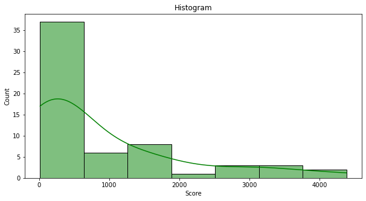

```python
plt.figure(figsize=(10,5))
plt.title("Histogram")
plt.xlabel("Score")
plt.ylabel("Count")
sns.histplot(data, x='Score', color='green', kde=True)
plt.show()
```

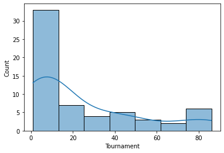

```python
sns.histplot(data, x='Tournament', kde=True);
```

Above graphs indicate that dataset is RightSkewed or Positively Skewed

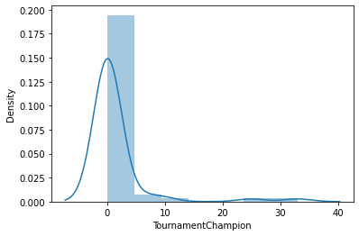

```python
sns.distplot(data.TournamentChampion);
```

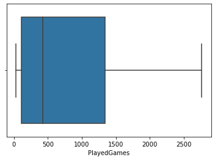

```python
sns.boxplot(x=data['PlayedGames']);
```

Indicated positive skew

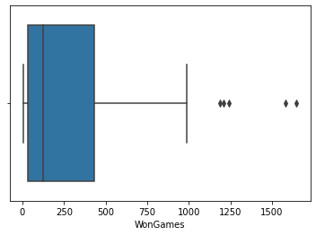

```python
sns.boxplot(x=data['WonGames']);
```

Indicates the presence of outliers

```python
data.corr()
```

|  | Tournament | Score | PlayedGames | WonGames | DrawnGames | LostGames | BasketScored | BasketGiven | TournamentChampion | Runner-up | TeamLaunch | HighestPositionHeld |
| --- | --- | --- | --- | --- | --- | --- | --- | --- | --- | --- | --- | --- |
| Tournament | 1.000000 | 0.981258 | 0.998683 | 0.971749 | 0.989295 | 0.949350 | 0.974867 | 0.987781 | 0.589304 | 0.645924 | -0.624021 | -0.708002 |
| Score | 0.981258 | 1.000000 | 0.979687 | 0.997232 | 0.958090 | 0.878780 | 0.996634 | 0.943801 | 0.715014 | 0.764819 | -0.565516 | -0.669215 |
| PlayedGames | 0.998683 | 0.979687 | 1.000000 | 0.967486 | 0.993972 | 0.955925 | 0.969970 | 0.990020 | 0.575072 | 0.633101 | -0.605568 | -0.711065 |
| WonGames | 0.971749 | 0.997232 | 0.967486 | 1.000000 | 0.939416 | 0.851436 | 0.999312 | 0.925745 | 0.752904 | 0.797849 | -0.567724 | -0.647819 |
| DrawnGames | 0.989295 | 0.958090 | 0.993972 | 0.939416 | 1.000000 | 0.972786 | 0.942234 | 0.992479 | 0.503378 | 0.566021 | -0.593550 | -0.720248 |
| LostGames | 0.949350 | 0.878780 | 0.955925 | 0.851436 | 0.972786 | 1.000000 | 0.857843 | 0.985041 | 0.324025 | 0.391645 | -0.610102 | -0.726172 |
| BasketScored | 0.974867 | 0.996634 | 0.969970 | 0.999312 | 0.942234 | 0.857843 | 1.000000 | 0.931079 | 0.743847 | 0.791041 | -0.578209 | -0.648672 |
| BasketGiven | 0.987781 | 0.943801 | 0.990020 | 0.925745 | 0.992479 | 0.985041 | 0.931079 | 1.000000 | 0.471618 | 0.533448 | -0.631105 | -0.727323 |
| TournamentChampion | 0.589304 | 0.715014 | 0.575072 | 0.752904 | 0.503378 | 0.324025 | 0.743847 | 0.471618 | 1.000000 | 0.971533 | -0.314434 | -0.304307 |
| Runner-up | 0.645924 | 0.764819 | 0.633101 | 0.797849 | 0.566021 | 0.391645 | 0.791041 | 0.533448 | 0.971533 | 1.000000 | -0.342955 | -0.359191 |
| TeamLaunch | -0.624021 | -0.565516 | -0.605568 | -0.567724 | -0.593550 | -0.610102 | -0.578209 | -0.631105 | -0.314434 | -0.342955 | 1.000000 | 0.602674 |
| HighestPositionHeld | -0.708002 | -0.669215 | -0.711065 | -0.647819 | -0.720248 | -0.726172 | -0.648672 | -0.727323 | -0.304307 | -0.359191 | 0.602674 | 1.000000 |

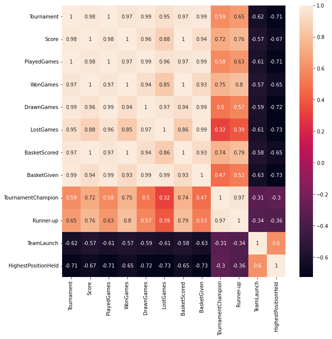

```python
fig,ax = plt.subplots(figsize=(10,10))
sns.heatmap(data.corr(),annot=True);
```

->Remaining are almost positively correlated

->Runnerup and TournamentChampion have 30% and 70% correlation with the other fields.

->Overall, the given data is highly correlated

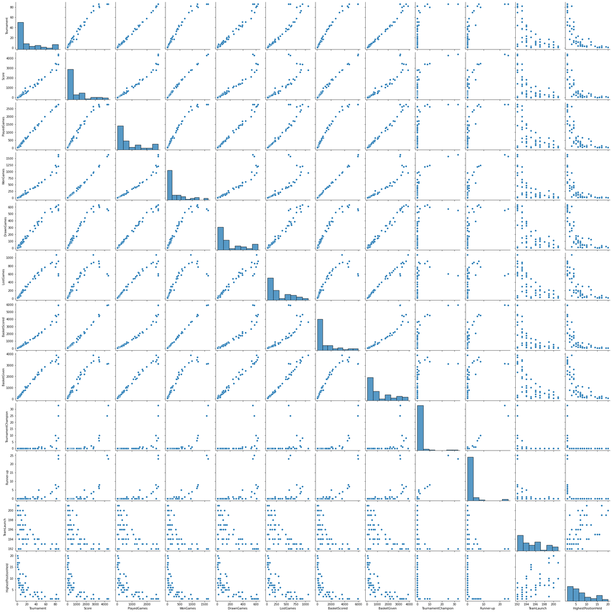

```python
sns.pairplot(data);
```

# 2 Q3

1.Quality :- The data given in the dataset is incomplete as it does not provide complete information regarding the last

Team(Team61). But it is one among the top 10 Highpositioned teams.

2.Quantity :- It has an information about 61 Teams but doesn't mentioned among the members of the team and their

performance.If we know the team members capability in different aspects of game we can analyse and give conclusion about

their position and winning chances of game.

3.Variety :- Information related to wongames, lostgames, Basketgiven, Basketscored were given. Along with this if they had

given the score at each level, in columns we can compare and know at which level they have raised or dropped

their score.

4.Veracity :- Though given dataset is small we cannot accurately predict results as some of the values are not

mentioned(NaN). As a result our assumptions might be true or false.

6.Skewness :- Almost positive (or) right skewed information. Most of the information for a particular category tend to have

most of its data on left side with its tail on right side.(we conclude this by observing describe table and graphs).

7.Outliers :- As we see a huge difference between Q3 or 75% and maximum value. we could suggest the presence of outliers.

8.The information given consists of data related to very old teams which might not be that much useful for performing and

predicting analysis to present scenario as the performance and capability of old team and newly updated team are different.

9.Though there were no missing and duplicated values, the data contains non-numeric values which does not make any use for

carrying out analysis.

10.Data provides overall team information irrespective of score won by each member of team at different levels of game.

# PART-3

```python
path = 'DS+-+Part3+-+CompanyX_EU (1).csv'
cust = pd.read_csv(path)
cust
```

|  | Startup | Product | Funding | Event | Result | OperatingState |
| --- | --- | --- | --- | --- | --- | --- |
| 0 | 2600Hz | 2600hz.com | NaN | Disrupt SF 2013 | Contestant | Operating |
| 1 | 3DLT | 3dlt.com | $630K | Disrupt NYC 2013 | Contestant | Closed |
| 2 | 3DPrinterOS | 3dprinteros.com | NaN | Disrupt SF 2016 | Contestant | Operating |
| 3 | 3Dprintler | 3dprintler.com | $1M | Disrupt NY 2016 | Audience choice | Operating |
| 4 | 42 Technologies | 42technologies.com | NaN | Disrupt NYC 2013 | Contestant | Operating |
| ... | ... | ... | ... | ... | ... | ... |
| 657 | Zivity | zivity.com | $8M | TC40 2007 | Contestant | Operating |
| 658 | Zmorph | zmorph3d.com | $1M | - | Audience choice | Operating |
| 659 | Zocdoc | zocdoc.com | $223M | TC40 2007 | Contestant | Operating |
| 660 | Zula | zulaapp.com | $3.4M | Disrupt SF 2013 | Audience choice | Operating |
| 661 | Zumper | zumper.com | $31.5M | Disrupt SF 2012 | Finalist | Operating |

662 rows × 6 columns

```python
cust.head()
```

|  | Startup | Product | Funding | Event | Result | OperatingState |
| --- | --- | --- | --- | --- | --- | --- |
| 0 | 2600Hz | 2600hz.com | NaN | Disrupt SF 2013 | Contestant | Operating |
| 1 | 3DLT | 3dlt.com | $630K | Disrupt NYC 2013 | Contestant | Closed |
| 2 | 3DPrinterOS | 3dprinteros.com | NaN | Disrupt SF 2016 | Contestant | Operating |
| 3 | 3Dprintler | 3dprintler.com | $1M | Disrupt NY 2016 | Audience choice | Operating |
| 4 | 42 Technologies | 42technologies.com | NaN | Disrupt NYC 2013 | Contestant | Operating |

```python
cust.info()
```

```
<class 'pandas.core.frame.DataFrame'>
RangeIndex: 662 entries, 0 to 661
Data columns (total 6 columns):
 #   Column          Non-Null Count  Dtype
---  ------          --------------  -----
 0   Startup         662 non-null    object
 1   Product         656 non-null    object
 2   Funding         448 non-null    object
 3   Event           662 non-null    object
 4   Result          662 non-null    object
 5   OperatingState  662 non-null    object
dtypes: object(6)
memory usage: 31.2+ KB
```

```python
cust.shape
```

```
(662, 6)
```

```python
#3Q2A.Datatypes
cust.dtypes
```

```
Startup           object
Product           object
Funding           object
Event             object
Result            object
OperatingState    object
dtype: object
```

```python
#3Q2B.Null values
cust.isnull().sum()
```

```
Startup             0
Product             6
Funding           214
Event               0
Result              0
OperatingState      0
dtype: int64
```

```python
#3Q3A. Dropping null values
cust.dropna().copy(deep=True)
```

|  | Startup | Product | Funding | Event | Result | OperatingState |
| --- | --- | --- | --- | --- | --- | --- |
| 1 | 3DLT | 3dlt.com | $630K | Disrupt NYC 2013 | Contestant | Closed |
| 3 | 3Dprintler | 3dprintler.com | $1M | Disrupt NY 2016 | Audience choice | Operating |
| 5 | 5to1 | 5to1.com | $19.3M | TC50 2009 | Contestant | Acquired |
| 6 | 8 Securities | 8securities.com | $29M | Disrupt Beijing 2011 | Finalist | Operating |
| 10 | AdhereTech | adheretech.com | $1.8M | Hardware Battlefield 2014 | Contestant | Operating |
| ... | ... | ... | ... | ... | ... | ... |
| 657 | Zivity | zivity.com | $8M | TC40 2007 | Contestant | Operating |
| 658 | Zmorph | zmorph3d.com | $1M | - | Audience choice | Operating |
| 659 | Zocdoc | zocdoc.com | $223M | TC40 2007 | Contestant | Operating |
| 660 | Zula | zulaapp.com | $3.4M | Disrupt SF 2013 | Audience choice | Operating |
| 661 | Zumper | zumper.com | $31.5M | Disrupt SF 2012 | Finalist | Operating |

446 rows × 6 columns

```python
cust1 = cust.dropna().copy(deep=True)
cust1
```

|  | Startup | Product | Funding | Event | Result | OperatingState |
| --- | --- | --- | --- | --- | --- | --- |
| 1 | 3DLT | 3dlt.com | $630K | Disrupt NYC 2013 | Contestant | Closed |
| 3 | 3Dprintler | 3dprintler.com | $1M | Disrupt NY 2016 | Audience choice | Operating |
| 5 | 5to1 | 5to1.com | $19.3M | TC50 2009 | Contestant | Acquired |
| 6 | 8 Securities | 8securities.com | $29M | Disrupt Beijing 2011 | Finalist | Operating |
| 10 | AdhereTech | adheretech.com | $1.8M | Hardware Battlefield 2014 | Contestant | Operating |
| ... | ... | ... | ... | ... | ... | ... |
| 657 | Zivity | zivity.com | $8M | TC40 2007 | Contestant | Operating |
| 658 | Zmorph | zmorph3d.com | $1M | - | Audience choice | Operating |
| 659 | Zocdoc | zocdoc.com | $223M | TC40 2007 | Contestant | Operating |
| 660 | Zula | zulaapp.com | $3.4M | Disrupt SF 2013 | Audience choice | Operating |
| 661 | Zumper | zumper.com | $31.5M | Disrupt SF 2012 | Finalist | Operating |

446 rows × 6 columns

```python
cust1['Funding'].sample(5)
```

```
161    $4.3M
65       $2M
354      $4M
454    $145K
465    $7.7M
Name: Funding, dtype: object
```

```python
cust1.loc[:,'Funds_in_million'] = cust1['Funding'].apply(lambda x: float(x[1:-1])/1000if x[-1] == 'K' else (float(x[1:-1])*1000 if x[-1] == 'B' else float(x[1:-1])))
```

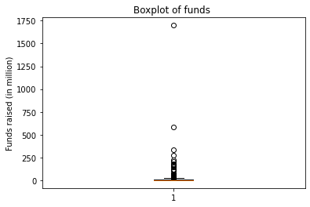

```python
#3Q3C Boxplot for funds in million
plot = plt.boxplot(cust1.Funds_in_million)
plt.title("Boxplot of funds ")
plt.ylabel("Funds raised (in million)");
```

```python
#3Q3D Number of outliers greater than upper fence
upper_fence = plot['caps'][1].get_data()[1][1]
upper_fence
print(f'Number of outliers = {len(cust1[cust1.Funds_in_million > upper_fence])}')
cust1[cust1.Funds_in_million > upper_fence]
```

```
Number of outliers = 60
```

|  | Startup | Product | Funding | Event | Result | OperatingState | Funds_in_million |
| --- | --- | --- | --- | --- | --- | --- | --- |
| 6 | 8 Securities | 8securities.com | $29M | Disrupt Beijing 2011 | Finalist | Operating | 29.0 |
| 31 | Anyclip | anyclip.com | $24M | TC50 2009 | Finalist | Operating | 24.0 |
| 40 | Artsy | artsy.net | $50.9M | Disrupt NYC 2010 | Contestant | Operating | 50.9 |
| 49 | Badgeville | badgeville.com | $40M | Disrupt SF 2010 | Finalist | Acquired | 40.0 |
| 56 | Betterment | betterment.com | $205M | Disrupt NYC 2010 | Finalist | Operating | 205.0 |
| 108 | Clickable | clickable.com | $32.5M | TC40 2007 | Finalist | Acquired | 32.5 |
| 113 | Cloudflare | cloudflare.com | $182.1M | Disrupt SF 2010 | Runner up | Operating | 182.1 |
| 128 | Credit Sesame | creditsesame.com | $35.4M | Disrupt SF 2010 | Contestant | Operating | 35.4 |
| 130 | CrowdFlower Inc. | crowdflower.com | $38M | TC50 2009 | Contestant | Operating | 38.0 |
| 132 | Cubic Telecom | cubictelecom.com | $37.1M | TC40 2007 | Contestant | Operating | 37.1 |
| 138 | DataSift | datasift.com | $72M | Disrupt SF 2010 | Finalist | Operating | 72.0 |
| 139 | DataXu | dataxu.com | $64M | TC50 2009 | Contestant | Operating | 64.0 |
| 154 | Dropbox | dropbox.com | $1.7B | TC50 2008 | Contestant | Operating | 1700.0 |
| 166 | Enigma | enigma.io | $34.6M | Disrupt NYC 2013 | Winner | Operating | 34.6 |
| 172 | EverythingMe | everything.me | $35.5M | Disrupt NYC 2011 | Contestant | Closed | 35.5 |
| 179 | Famo.us | famo.us | $30.1M | Disrupt SF 2012 | Contestant | Operating | 30.1 |
| 180 | Farmigo | farmigo.com | $26M | Disrupt SF 2011 | Finalist | Operating | 26.0 |
| 188 | Fitbit | fitbit.com | $66M | TC50 2008 | Finalist | Ipo | 66.0 |
| 191 | Flock | flock.com | $28.3M | TC40 2007 | Contestant | Acquired | 28.3 |
| 209 | Getaround | getaround.com | $103M | Disrupt NYC 2011 | Winner | Operating | 103.0 |
| 213 | Gild | gild.com | $25.9M | Disrupt SF 2010 | Contestant | Acquired | 25.9 |
| 215 | Glide | glide.me | $36.5M | Disrupt NYC 2013 | Audience choice | Operating | 36.5 |
| 225 | Grockit | grockit.com | $44.7M | TC50 2008 | Finalist | Acquired | 44.7 |
| 231 | HackerRank | hackerrank.com | $24.2M | Disrupt SF 2012 | Contestant | Operating | 24.2 |
| 271 | Ionic Security | ionicsecurity.com | $122.4M | Disrupt SF 2012 | Contestant | Operating | 122.4 |
| 276 | IZEA | izea.com | $34.9M | Disrupt NYC 2010 | Contestant | Ipo | 34.9 |
| 279 | Jiff | jiff.com | $67.8M | Disrupt SF 2011 | Contestant | Acquired | 67.8 |
| 282 | Kaltura | kaltura.com | $166.1M | TC40 2007 | Audience choice | Operating | 166.1 |
| 302 | Layer | layer.com | $42.1M | Disrupt SF 2013 | Winner | Operating | 42.1 |
| 305 | LearnVest | learnvest.com | $69M | TC50 2009 | Contestant | Acquired | 69.0 |
| 313 | LiveIntent | liveintent.com | $65.1M | Disrupt NYC 2010 | Audience choice | Operating | 65.1 |
| 325 | Lystable | lystable.com | $25.1M | Disrupt London 2015 | Finalist | Operating | 25.1 |
| 346 | Mint | mint.com | $31.8M | TC40 2007 | Winner | Acquired | 31.8 |
| 389 | OrderWithMe | orderwithme.com | $37M | Disrupt Beijing 2011 | Winner | Operating | 37.0 |
| 393 | Osmo | playosmo.com | $38.5M | Disrupt SF 2013 | Contestant | Operating | 38.5 |
| 394 | Ossia | ossia.com | $25.5M | Disrupt SF 2013 | Runner up | Operating | 25.5 |
| 398 | Owlet Baby Care | owletcare.com | $24M | Hardware Battlefield 2014 | Runner up | Operating | 24.0 |
| 427 | Postmates | postmates.com | $278M | Disrupt SF 2011 | Contestant | Operating | 278.0 |
| 432 | Prism Skylabs | prism.com | $24M | Disrupt SF 2011 | Runner up | Operating | 24.0 |
| 435 | PubMatic | pubmatic.com | $63M | TC40 2007 | Contestant | Operating | 63.0 |
| 460 | Roadie | roadie.com | $25M | Disrupt NYC 2014 | Audience choice | Operating | 25.0 |
| 471 | SeatGeek | seatgeek.com | $160M | TC50 2009 | Contestant | Operating | 160.0 |
| 546 | StyleSeat | styleseat.com | $40M | Disrupt NYC 2011 | Contestant | Operating | 40.0 |
| 555 | Symphony Commerce | symphonycommerce.com | $47.4M | Disrupt NYC 2011 | Contestant | Operating | 47.4 |
| 560 | Talkdesk | talkdesk.com | $24.5M | Disrupt NYC 2012 | Contestant | Operating | 24.5 |
| 581 | TouchPal | touchpal.com | $25M | Disrupt Beijing 2011 | Finalist | Operating | 25.0 |
| 593 | TrueCar | truecar.com | $332.4M | TC50 2008 | Contestant | Ipo | 332.4 |
| 598 | UberConference | uberconference.com | $35M | Disrupt NYC 2012 | Winner | Operating | 35.0 |
| 606 | Upwork | upwork.com | $168.8M | TC50 2009 | Audience choice | Operating | 168.8 |
| 615 | VideoSurf | videosurf.com | $28M | TC50 2008 | Contestant | Acquired | 28.0 |
| 625 | Voxy | voxy.com | $30.8M | Disrupt SF 2010 | Contestant | Operating | 30.8 |
| 643 | Xobni | yahoo.com | $41.8M | TC40 2007 | Contestant | Acquired | 41.8 |
| 644 | Yammer | yammer.com | $142M | TC50 2008 | Winner | Acquired | 142.0 |
| 647 | Yext | yext.com | $117.8M | TC50 2009 | Contestant | Ipo | 117.8 |
| 649 | YouNow | younow.com | $26M | Disrupt SF 2011 | Contestant | Operating | 26.0 |
| 650 | YourMechanic | yourmechanic.com | $28M | Disrupt SF 2012 | Winner | Operating | 28.0 |
| 654 | ZEFR | zefr.com | $62.1M | Disrupt NYC 2010 | Contestant | Operating | 62.1 |
| 656 | Zenefits | zenefits.com | $583.6M | Disrupt NYC 2013 | Finalist | Operating | 583.6 |
| 659 | Zocdoc | zocdoc.com | $223M | TC40 2007 | Contestant | Operating | 223.0 |
| 661 | Zumper | zumper.com | $31.5M | Disrupt SF 2012 | Finalist | Operating | 31.5 |

```python
cust1.drop(cust1[cust1.Funds_in_million > upper_fence].index, inplace=True)
```

```python
#3Q3E frequency of the Operating State features classes
cust1.OperatingState.value_counts()
```

```
Operating    275
Closed        56
Acquired      55
Name: OperatingState, dtype: int64
```

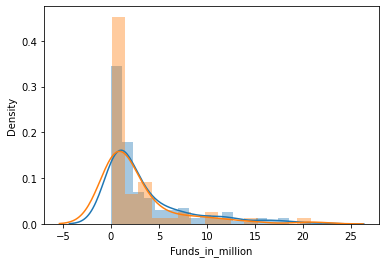

```python
#3Q4A Any significance difference between still operating and closed
sns.distplot(cust1.loc[cust1.OperatingState == 'Operating', 'Funds_in_million'])
sns.distplot(cust1.loc[cust1.OperatingState == 'Closed', 'Funds_in_million']);
```

-> Distributions are almost similar. -> Both of them follow same pattern(initially increase and gradually decrease). -> Though we have enough sample size distributions are not normal.

# 3Q4B Null and alternative hypothesis

Null hypothesis(H0) :- No significant difference between two means.

Alternative hypothesis(Ha) :- There is significant difference between two

means.

```python
# 3Q4D Copy of the original data frame
cust2 = cust.copy(deep=True)
cust2
```

|  | Startup | Product | Funding | Event | Result | OperatingState |
| --- | --- | --- | --- | --- | --- | --- |
| 0 | 2600Hz | 2600hz.com | NaN | Disrupt SF 2013 | Contestant | Operating |
| 1 | 3DLT | 3dlt.com | $630K | Disrupt NYC 2013 | Contestant | Closed |
| 2 | 3DPrinterOS | 3dprinteros.com | NaN | Disrupt SF 2016 | Contestant | Operating |
| 3 | 3Dprintler | 3dprintler.com | $1M | Disrupt NY 2016 | Audience choice | Operating |
| 4 | 42 Technologies | 42technologies.com | NaN | Disrupt NYC 2013 | Contestant | Operating |
| ... | ... | ... | ... | ... | ... | ... |
| 657 | Zivity | zivity.com | $8M | TC40 2007 | Contestant | Operating |
| 658 | Zmorph | zmorph3d.com | $1M | - | Audience choice | Operating |
| 659 | Zocdoc | zocdoc.com | $223M | TC40 2007 | Contestant | Operating |
| 660 | Zula | zulaapp.com | $3.4M | Disrupt SF 2013 | Audience choice | Operating |
| 661 | Zumper | zumper.com | $31.5M | Disrupt SF 2012 | Finalist | Operating |

662 rows × 6 columns

```python
# 3Q4I
cust1[cust1.Event.apply(lambda x:'Disrupt' in x)].Event.value_counts()
```

```
Disrupt NY 2015         21
Disrupt NYC 2013        19
Disrupt SF 2011         19
Disrupt SF 2013         19
Disrupt SF 2014         19
Disrupt NYC 2012        19
Disrupt SF 2015         19
Disrupt SF 2016         17
Disrupt NY 2016         16
Disrupt SF 2012         15
Disrupt NYC 2011        15
Disrupt NYC 2014        15
Disrupt SF 2010         13
Disrupt London 2015     11
Disrupt NYC 2010        10
Disrupt London 2016     10
Disrupt EU 2014         10
Disrupt EU 2013          9
Disrupt Beijing 2011     4
Name: Event, dtype: int64
```

```python
# 3Q4I
event = cust1[cust1.Event.apply(lambda x:'Disrupt' in x and int(x[-4:]) > 2012)].Event
event
```

```
1         Disrupt NYC 2013
3          Disrupt NY 2016
13         Disrupt SF 2015
14     Disrupt London 2016
16         Disrupt SF 2015
              ...
635        Disrupt NY 2015
641       Disrupt NYC 2013
642        Disrupt SF 2014
646    Disrupt London 2015
660        Disrupt SF 2013
Name: Event, Length: 185, dtype: object
```